# 💳 Capstone Project: Credit Card Fraud Detection

# 🤖 Machine Learning Models

### Models Evaluated:

| Model | Why Used |
| --- | --- |
| **Logistic Regression** | Simple baseline, interpretable |
| **Random Forest** | Handles imbalance well, robust |
| **XGBoost** | High performance, gradient boosting |

We train 6 models (3 algorithms × 2 strategies) and compare AUPRC, AUC-ROC, and business-cost-weighted F1 on the held-out test set.

### Key Metrics Used:

False Negatives are typically 5-20X more costly than False Positives. This asymmetry directly shapes our choice of:

- Evaluation metric: AUPRC (Area Under the Precision-Recall Curve) instead of AUC-ROC, because AUPRC is far more sensitive to performance on the minority (fraud) class.
- Imbalance strategy: Both SMOTE and Class Weights, with the business cost driving the final model selection.
- Decision threshold: Tuned post-training to favor recall (catching fraud) over precision.

> 🎯 For fraud detection, **Recall is most critical** — missing a fraud is costly!

```python
# ──────────────────────────────────────────────────────────────────────────────
# SMOTE models  (imbalanced-learn Pipeline keeps SMOTE inside the training fold)
# ──────────────────────────────────────────────────────────────────────────────
smote = SMOTE(random_state=42, k_neighbors=5)

smote_models = {
    'LR + SMOTE': ImbPipeline(steps=[
        ('smote', smote),
        ('scaler', StandardScaler()),
        ('clf', LogisticRegression(max_iter=1000, random_state=42))
    ]),
    'RF + SMOTE': ImbPipeline(steps=[
        ('smote', smote),
        ('clf', RandomForestClassifier(n_estimators=200, n_jobs=-1, random_state=42))
    ]),
    'XGB + SMOTE': ImbPipeline(steps=[
        ('smote', smote),
        ('clf', XGBClassifier(
            n_estimators=300, learning_rate=0.05, max_depth=6,
            use_label_encoder=False, eval_metric='logloss',
            n_jobs=-1, random_state=42
        ))
    ])
}

print('Training SMOTE models...')
for name, pipe in smote_models.items():
    pipe.fit(X_train, y_train)
    print(f'  ✓ {name}')
```

```
Training SMOTE models...
  ✓ LR + SMOTE
  ✓ RF + SMOTE
  ✓ XGB + SMOTE
```

```python
# ──────────────────────────────────────────────────────────────────────────────
# Class-weight models
# ──────────────────────────────────────────────────────────────────────────────
cw_models = {
    'LR + CW': Pipeline(steps=[
        ('scaler', StandardScaler()),
        ('clf', LogisticRegression(class_weight='balanced', max_iter=1000, random_state=42))
    ]),
    'RF + CW': RandomForestClassifier(
        n_estimators=200, class_weight='balanced', n_jobs=-1, random_state=42
    ),
    'XGB + CW': XGBClassifier(
        n_estimators=300, learning_rate=0.05, max_depth=6,
        scale_pos_weight=(y_train == 0).sum() / (y_train == 1).sum(),  # equivalent to 'balanced'
        use_label_encoder=False, eval_metric='logloss',
        n_jobs=-1, random_state=42
    )
}

print('Training Class-Weight models...')
for name, model in cw_models.items():
    model.fit(X_train, y_train)
    print(f'  ✓ {name}')
```

```
Training Class-Weight models...
  ✓ LR + CW
  ✓ RF + CW
  ✓ XGB + CW
```

# 🏆 Best Models

```python
# ============================================================
# SLIDE: Model Comparison Table & Chart
# ============================================================
all_models = {**smote_models, **cw_models}
results = []

# Business cost constants (adjust as needed)
COST_FN = 120   # USD: missed fraud (transaction loss + chargeback)
COST_FP = 8     # USD: blocked legit transaction (customer friction)

for name, model in all_models.items():
    y_proba = model.predict_proba(X_test)[:, 1]

    auprc   = average_precision_score(y_test, y_proba)
    auc_roc = roc_auc_score(y_test, y_proba)

    # Threshold optimised for maximum F1 on PR curve
    prec, rec, thresholds = precision_recall_curve(y_test, y_proba)
    f1_scores = 2 * prec * rec / (prec + rec + 1e-9)
    best_thresh = thresholds[np.argmax(f1_scores[:-1])]
    y_pred = (y_proba >= best_thresh).astype(int)

    cm = confusion_matrix(y_test, y_pred)
    tn, fp, fn, tp = cm.ravel()
    recall    = tp / (tp + fn)
    precision = tp / (tp + fp) if (tp + fp) > 0 else 0
    f1        = f1_score(y_test, y_pred)
    biz_cost  = fn * COST_FN + fp * COST_FP

    results.append({
        'Model': name,
        'AUPRC': round(auprc, 4),
        'AUC-ROC': round(auc_roc, 4),
        'Recall': round(recall, 4),
        'Precision': round(precision, 4),
        'F1': round(f1, 4),
        'FN': fn,
        'FP': fp,
        f'Biz Cost ($FN={COST_FN}, $FP={COST_FP})': f'${biz_cost:,}'
    })

# Append the Isolation Forest result
results.append(iso_result)

results_df = pd.DataFrame(results).sort_values('AUPRC', ascending=False).reset_index(drop=True)

print('=' * 100)
print('MODEL COMPARISON TABLE — Supervised + Anomaly Detection (sorted by AUPRC ↓)')
print('=' * 100)
print(results_df.to_string(index=False))
print('=' * 100)
print()
print('📝 Note: Isolation Forest is unsupervised — it never uses fraud labels during training.')
print('         Its AUPRC reflects anomaly-score ranking quality, not learned class boundaries.')
```

[output not shown]

```
====================================================================================================
MODEL COMPARISON TABLE — Supervised + Anomaly Detection (sorted by AUPRC ↓)
====================================================================================================
                          Model  AUPRC  AUC-ROC  Recall  Precision     F1  FN  FP Biz Cost ($FN=120, $FP=8)
                       XGB + CW 0.8195   0.9691  0.7684     0.9865 0.8639  22   1                    $2,648
                        RF + CW 0.8136   0.9340  0.8211     0.8764 0.8478  17  11                    $2,128
                     RF + SMOTE 0.8103   0.9512  0.8000     0.8736 0.8352  19  11                    $2,368
                    XGB + SMOTE 0.8086   0.9700  0.7474     0.9342 0.8304  24   5                    $2,920
                     LR + SMOTE 0.6754   0.9619  0.7474     0.8875 0.8114  24   9                    $2,952
                        LR + CW 0.6719   0.9657  0.7579     0.8780 0.8136  23  10                    $2,840
Isolation Forest (unsupervised) 0.0881   0.9322  0.2316     0.1880 0.2075  73  95                    $9,520
====================================================================================================

📝 Note: Isolation Forest is unsupervised — it never uses fraud labels during training.
         Its AUPRC reflects anomaly-score ranking quality, not learned class boundaries.
```

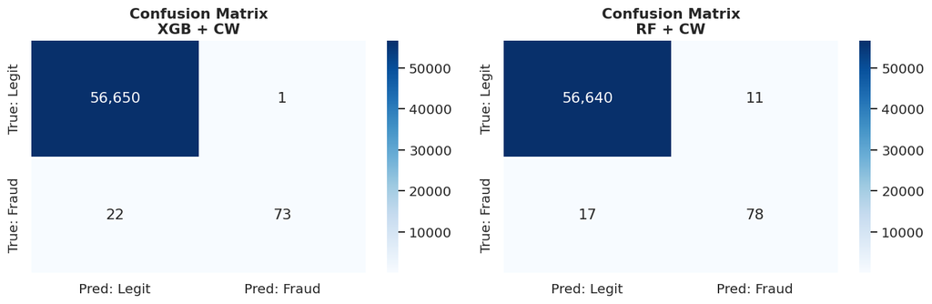

```python
# ============================================================
# SLIDE: Best Model — Confusion Matrix
# Confusion matrices for top 2 models
# ============================================================

top2 = results_df.head(2)['Model'].tolist()
fig, axes = plt.subplots(1, 2, figsize=(12, 4))

for ax, name in zip(axes, top2):
    model   = all_models[name]
    y_proba = model.predict_proba(X_test)[:, 1]
    prec, rec, thresholds = precision_recall_curve(y_test, y_proba)
    f1s = 2 * prec * rec / (prec + rec + 1e-9)
    best_thresh = thresholds[np.argmax(f1s[:-1])]
    y_pred = (y_proba >= best_thresh).astype(int)

    cm = confusion_matrix(y_test, y_pred)
    sns.heatmap(cm, annot=True, fmt=',d', cmap='Blues', ax=ax,
                xticklabels=['Pred: Legit', 'Pred: Fraud'],
                yticklabels=['True: Legit', 'True: Fraud'])
    ax.set_title(f'Confusion Matrix\n{name}', fontweight='bold')

plt.tight_layout()
plt.savefig('fig_confusion_matrices.png', dpi=150, bbox_inches='tight')
plt.show()
```